# ENG

# West Atlantic Skipjack MSE

## (*Katsuwonus pelamis*)

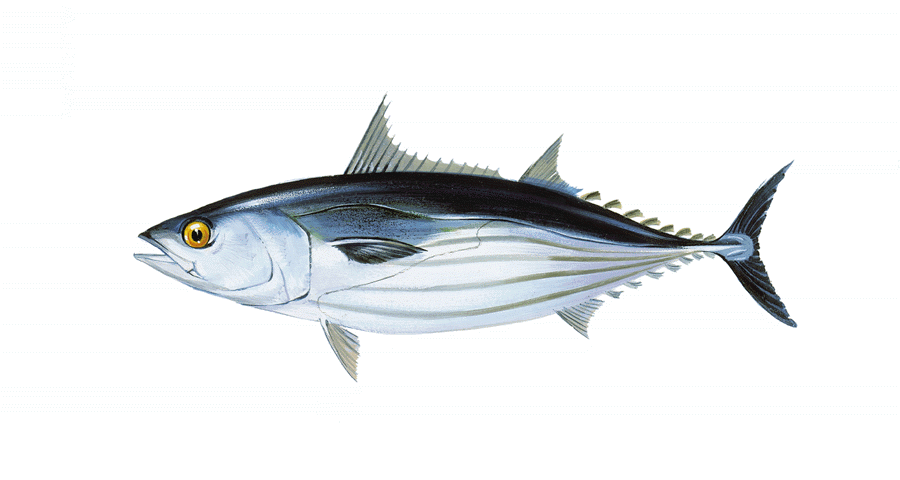

# Overview

## ECP adoption in 2025

## EC evaluation not started

# History

## The western skipjack tuna stock has been identified as a priority for Management Strategy Evaluation (MSE) due to its importance in tropical tuna fisheries. Initial guidance was provided in Rec. 21-01 (https://www.iccat.int/Documents/Recs/compendiopdf-e/2021-01-e.pdf), which emphasized the need to improve the management of tropical tunas through the use of harvest control rules and MSE. Rec. 21-01 (https://www.iccat.int/Documents/Recs/compendiopdf-e/2021-01-e.pdf), along with Res. 15-07 (https://www.iccat.int/Documents/Recs/compendiopdf-e/2015-07-e.pdf) and Rec. 19-14 (https://www.iccat.int/Documents/Recs/compendiopdf-e/2019-14-e.pdf), established a general framework for the development of MSE across priority stocks, including skipjack. The SCRS identified skipjack (SKJ) as a priority stock for MSE, particularly due to its involvement in mixed fisheries with yellowfin and bigeye tuna. In line with these directives, the SCRS initiated the development of an MSE framework for skipjack, with formal work beginning after the 2021 Tropical Tunas Species Group meeting. This process is aligned with the Commission’s objective of adopting a harvest strategy for skipjack by 2025.

# Contents

## Operating Models

## Management Objectives

## Candidate Management Procedure

## Management Procedure

## Exceptional Circumstances

## References

# Operating Models

## The Operating Models (OMs) has been developed. Progress toward MSE development for Western SKJ is reflected in a series of SCRS and CVSP documents: - **[Huynh et al. (2020)](https://www.iccat.int/Documents/CVSP/CV077_2020/n_8/CV077080121.pdf)**: Demonstration of the Western Atlantic skipjack tuna MSE framework, including operating-model conditioning based on Brazilian bait-boat and handline fleet data - **[Mourato et al. (2022)](https://www.iccat.int/Documents/CVSP/CV079_2022/n_1/CV079010384.pdf)**: Updated operating models and initial evaluation of preliminary management procedures across 11 OMs encompassing key life‑history uncertainties - **[Sant’Ana & Mourato (2023)](https://www.iccat.int/Documents/CVSP/CV080_2023/n_2/CV080020260.pdf)**: Development of candidate management procedures with tuning rules and robustness checks across operating models - **[Sant’Ana & Mourato (2024)](https://www.iccat.int/Documents/CVSP/CV081_2024/n_2/CV08102162.pdf)**: Status update and CMP evaluation results including performance metrics aligned with ICCAT objectives These documents provide critical detail on the conditioning of operating models, robustness testing, and how candidate management procedures respond under varying assumptions about stock productivity and recruitment.

# Materials

## More materials can be found in Reference

# Management Objectives

# [**Rec. 24-04**](https://www.iccat.int/Documents/Recs/compendiopdf-e/2024-04-e.pdf)

## Stock Status

## Prob. >= 60% in green quadrant

## Safety

## Prob. < 10% of stock falling below Blim

## Yield

## Maximize overall catch

## Stability

## TAC changes between periods +25%/-25%

# Candidate Management Procedure

## Many Candidate Management Procedures based on both index-based and assessment model-based harvest control rules (HCRs) have been developed. (Sant’Ana and Mourato, 2024)

# Management Procedure

## The Commission will adopt the MP in 2025

# Exceptional Circumstances

## The Commission will adopt the Exceptional Circumstances Protocol in 2025.

# References

## Materials

## Rec/Res

## Meetings

## SCRS Docs

## Others

## Updated: July 7, 2025

## Copyright © 2025 ICCAT. All rights reserved